# Milestone 2: Model Monitoring

Business Context:

Fashion Haven has successfully implemented a predictive model for sales revenue estimation based on their advertising campaigns across different media sources (TV, Newspaper, Radio). The model has been deployed in production, and it plays a crucial role in guiding the company's advertising budget allocation and overall marketing strategy. However, after the initial deployment, the company faces the challenge of monitoring the model's performance and ensuring its ongoing reliability and accuracy. Over time, the business environment may change, advertising trends could evolve, or external factors may impact customer behavior, all of which can influence the model's predictive capabilities. Fashion Haven needs to develop a robust model monitoring system to identify and address potential issues with the deployed sales revenue prediction model.

The goal of this model monitoring assignment is to implement a proactive approach to ensure the model's continued effectiveness and identify any degradation in its performance. By regularly monitoring the model, Fashion Haven can maintain the quality of predictions, make timely updates, and take corrective actions as needed.

The model monitoring system should provide the following key functionalities:

1. Data Drift Detection: The business environment is dynamic, and changes in customer behavior, market trends, or competitor strategies may cause data distribution to drift over time. The monitoring system should identify and measure data drift in the input features used by the model, helping the team understand how well the model adapts to new data.
2. Model Drift Checks: Regular calibration checks will ensure that the model's predicted probabilities align with the observed outcomes. If the model becomes miscalibrated, corrective actions should be taken to recalibrate it for accurate probability estimates.

## Creating endpoints (0 Mark)

This part of the project will check your skills related to model monitoring. We are providing the below codes to train and deploy the model. You can use these codes to do long-term monitoring checks. Watch the previous LVC recording and refer to the Week 8: Model Monitoring LVC notebook and MLS 8: Model Monitoring: AWS MLS notebook.

**General Imports**

```python
import json
import ast

import logging

import pandas as pd
import matplotlib.pyplot as plt
import seaborn as sns

from scipy.stats import ks_2samp, chi2_contingency, ttest_rel
```

```python
sns.set_context("talk")
```

**SageMaker Imports**

```python
import boto3 ## This is the AWS SDK for Python. It provides an easy-to-use, object-oriented API as well as low-level access to AWS services.
import sagemaker

from sagemaker.sklearn.estimator import SKLearn, SKLearnModel
from sagemaker.model_monitor import DataCaptureConfig
```

```
sagemaker.config INFO - Not applying SDK defaults from location: /etc/xdg/sagemaker/config.yaml
sagemaker.config INFO - Not applying SDK defaults from location: /root/.config/sagemaker/config.yaml
```

**Authentication**

```python
session = sagemaker.Session()
```

```
sagemaker.config INFO - Not applying SDK defaults from location: /etc/xdg/sagemaker/config.yaml
sagemaker.config INFO - Not applying SDK defaults from location: /root/.config/sagemaker/config.yaml
```

```python
try:
    aws_role = sagemaker.get_execution_role()
except ValueError:
    print('Local configuration is not complete; use SageMaker Studio')
```

```
sagemaker.config INFO - Not applying SDK defaults from location: /etc/xdg/sagemaker/config.yaml
sagemaker.config INFO - Not applying SDK defaults from location: /root/.config/sagemaker/config.yaml
```

```python
# My s3 bucket for milestone2 project
bucket = "vj-milestone-2-project"
```

```python
print(f"AWS execution role associated with the account {aws_role}\n")
print(f"Default bucket associated with the account: {session.default_bucket()}\n")
print(f"Created s3 bucket for this milestone2 project {bucket}\n")
print(f"Default boto region associated with the account: {session.boto_region_name}\n")
```

```
AWS execution role associated with the account arn:aws:iam::292827171942:role/service-role/AmazonSageMaker-ExecutionRole-20231012T142964

Default bucket associated with the account: sagemaker-us-east-1-292827171942

Created s3 bucket for this milestone2 project vj-milestone-2-project

Default boto region associated with the account: us-east-1
```

**Setup**

```python
monitoring_session = sagemaker.session.Session(
    default_bucket=bucket
)
```

```
sagemaker.config INFO - Not applying SDK defaults from location: /etc/xdg/sagemaker/config.yaml
sagemaker.config INFO - Not applying SDK defaults from location: /root/.config/sagemaker/config.yaml
```

```python
monitoring_session.default_bucket()
```

```
'vj-milestone-2-project'
```

**Model Training**

We use the `SKLearn` estimator to estimate a model from the training data.

```python
%%writefile gbr.py

import os
import joblib
import pandas as pd

# from sklearn.preprocessing import StandardScaler, OneHotEncoder
# from sklearn.compose import make_column_transformer

from sklearn.ensemble import GradientBoostingRegressor

# from sklearn.pipeline import make_pipeline

from sklearn.metrics import mean_squared_error
from sklearn.model_selection import train_test_split


def main():

    training_data_directory = "/opt/ml/input/data/train"
    model_output_directory = "/opt/ml/model"

    input_data_path = os.path.join(
        training_data_directory,
        "processed_data.csv"
    )

    data = pd.read_csv(input_data_path)

    target = 'Sales'


    X = data.drop(columns=['Sales'])
    y = data[target]

    Xtrain, Xtest, ytrain, ytest = train_test_split(
        X, y, test_size=0.2, random_state=42
    )


    model_gbr = GradientBoostingRegressor(
        max_depth=4,
        learning_rate=0.1,
        n_estimators=100
    )

    print("Training Gradient Boosting Regressor")

    model_gbr.fit(Xtrain, ytrain)

    print("Predicting on test data")

    ypred = model_gbr.predict(Xtest)

    print(f"RMSE: {mean_squared_error(ytest, ypred, squared=False)};")
    print(f"R-squared: {model_gbr.score(Xtest, ytest)};")

    model_output_path = os.path.join(model_output_directory, "model.joblib")

    print(f"Saving model to {model_output_path}")
    joblib.dump(model_gbr, model_output_path)


if __name__ == "__main__":
    main()
```

```
Overwriting gbr.py
```

```python
sklearn_gbr_estimator = SKLearn(
    entry_point="gbr.py",
    framework_version="1.0-1",
    role=aws_role,
    sagemaker_session=monitoring_session,
    instance_type="ml.m4.xlarge",
    instance_count=1,
    volume_size=1
)
```

*The model artifacts are stored in the `output` folder within the location created by the training job*

```python
sklearn_gbr_estimator.fit(
    inputs={
    'train': 's3://vj-milestone-2-project/pre-processing/output/processed_data/'
    },
    wait=False,
    job_name='2023-12-07-estimate-gbr-01'
)
```

```
INFO:sagemaker:Creating training-job with name: 2023-12-07-estimate-gbr-01
```

```
Using provided s3_resource
```

```python
sklearn_gbr_estimator.logs()
```

[output not shown]

[output cut: 49 more lines]

```
SM_CHANNEL_TRAIN=/opt/ml/input/data/train
PYTHONPATH=/opt/ml/code:/miniconda3/bin:/miniconda3/lib/python38.zip:/miniconda3/lib/python3.8:/miniconda3/lib/python3.8/lib-dynload:/miniconda3/lib/python3.8/site-packages
Invoking script with the following command:
/miniconda3/bin/python gbr.py
Training Gradient Boosting Regressor
Predicting on test data
RMSE: 0.7377160392372338;
R-squared: 0.9827578266638959;
Saving model to /opt/ml/model/model.joblib
2023-12-10 18:54:02,051 sagemaker-containers INFO     Reporting training SUCCESS

2023-12-10 18:54:27 Uploading - Uploading generated training model
2023-12-10 18:54:27 Completed - Training job completed
Training seconds: 120
Billable seconds: 120
```

```python
sklearn_gbr_estimator.model_data
```

```
's3://vj-milestone-2-project/2023-12-07-estimate-gbr-01/output/model.tar.gz'
```

```python
artifacts_gbr = "s3://vj-milestone-2-project/2023-12-07-estimate-gbr-01/output/model.tar.gz"
```

**Model Deployment**

```python
%%writefile inference.py

import os
import joblib

import pandas as pd

from io import StringIO


def model_fn(model_dir):
    '''
    This function is called when the server is instantiated for the first time.
    SageMaker injects the model directory (/opt/ml/model) when the function is
    called. We reference and load the model pipeline binary from this
    directory
    '''
    print(f"loading model.joblib from: {model_dir}")
    model_pipeline = joblib.load(os.path.join(model_dir, "model.joblib"))
    return model_pipeline


def input_fn(request_body, request_content_type):
    '''
    This function is called each time a prediction request is received.
    We check for the type of the input and restrict the inputs to csv files
    If we receive a csv input, we convert the input to a pandas DataFrame
    object. This DataFrame serves as an input to the model for prediction
    '''
    if request_content_type == "text/csv":
        data_df = pd.read_csv(StringIO(request_body))
        return data_df
    else:
        print("Received unknown input")
        pass


def predict_fn(input_data, model):
    '''
    This function is called each time a prediction request is received.
    SageMaker injects the processed input data from the input_fn and the model
    loaded from the model_fn as parameters
    '''
    return model.predict(input_data)
```

```
Overwriting inference.py
```

```python
# Creating model object
model_gbr = SKLearnModel(
    model_data=artifacts_gbr,
    role=aws_role,
    sagemaker_session=monitoring_session,
    entry_point="inference.py",
    framework_version="1.0-1"
)
```

```python
# Data Capture configuration
model_monitor_config = DataCaptureConfig(
    enable_capture=True,
    sampling_percentage=30, # Sample of 30% traffic will be logged or monitored.
    destination_s3_uri="s3://vj-milestone-2-project/2023-12-07-monitor-gbr-01/", # keep the numbering in sync with the model numbering to avoid uncessary S3 issues.
    capture_options=["REQUEST", "RESPONSE"],
)
```

```
sagemaker.config INFO - Not applying SDK defaults from location: /etc/xdg/sagemaker/config.yaml
sagemaker.config INFO - Not applying SDK defaults from location: /root/.config/sagemaker/config.yaml
```

```python
# Deploying the model with data_capture_config set to collect all the traffic from the endpoint.
predictor_gbr = model_gbr.deploy(
    endpoint_name='gbr-vj-01',
    instance_type="ml.m4.xlarge",
    initial_instance_count=1,
    data_capture_config=model_monitor_config,
    wait=False
)
```

```
INFO:sagemaker:Creating model with name: sagemaker-scikit-learn-2023-12-10-18-56-11-402
INFO:sagemaker:Creating endpoint-config with name gbr-vj-01
INFO:sagemaker:Creating endpoint with name gbr-vj-01
```

## Test data for monitoring

Read the advertising_synthetic.csv file

```python
test_df_ad_syn = pd.read_csv("s3://vj-milestone-2-project/data/proc_syn.csv")
```

Print the length and info of the dataframe

```python
len(test_df_ad_syn)
```

```
19
```

```python
test_df_ad_syn.info()
```

```
<class 'pandas.core.frame.DataFrame'>
RangeIndex: 19 entries, 0 to 18
Data columns (total 4 columns):
 #   Column     Non-Null Count  Dtype
---  ------     --------------  -----
 0   TV         19 non-null     float64
 1   Radio      19 non-null     float64
 2   Newspaper  19 non-null     float64
 3   Sales      19 non-null     float64
dtypes: float64(4)
memory usage: 736.0 bytes
```

Define the numeric features and the target variable

```python
numeric_features = ['TV', 'Radio', 'Newspaper']
target = ['Sales']
```

Define the variable called features and assign the numeric features columns

```python
features = numeric_features
```

```python
features
```

```
['TV', 'Radio', 'Newspaper']
```

Define the sample_Xtest and sample_ytest

```python
sample_Xtest = test_df_ad_syn[features]
sample_ytest = test_df_ad_syn['Sales']
```

```python
sample_Xtest.head()
```

|  | TV | Radio | Newspaper |
| --- | --- | --- | --- |
| 0 | 0.969852 | 0.981522 | 1.778945 |
| 1 | -1.197376 | 1.082808 | 0.669579 |
| 2 | -1.516155 | 1.528463 | 1.783549 |
| 3 | 0.052050 | 1.217855 | 1.286405 |
| 4 | 0.394182 | -0.841614 | 1.281802 |

```python
sample_ytest.head()
```

```
0    22.1
1    10.4
2     9.3
3    18.5
4    12.9
Name: Sales, dtype: float64
```

Define a SageMaker runtime and invoke the endpoint and check the status code

```python
sagemaker_runtime = boto3.client("sagemaker-runtime")
## This is the name of the AWS service that the client will interact with. The SageMaker Runtime service is used for invoking machine
## learning models deployed on SageMaker for real-time inference.
```

```python
# Make sure the enpoint is "InService", before you run this step.
# for _ in range(10):
#     response = sagemaker_runtime.invoke_endpoint(
#         EndpointName=predictor_gbr.endpoint_name,
#         Body=sample_Xtest.sample(10).to_csv(header=True, index=False).encode("utf-8"),
#         ContentType="text/csv"
#     )

response = sagemaker_runtime.invoke_endpoint(
    EndpointName=predictor_gbr.endpoint_name,
    Body=sample_Xtest.to_csv(header=True, index=False).encode("utf-8"),
    ContentType="text/csv"
)
```

```python
## Checking the status code of its response, confirming that the endpoint is REST-ful
response['ResponseMetadata']['HTTPStatusCode']
```

```
200
```

## Implementing long-term monitoring

Read the advertising dataset

```python
training_data = pd.read_csv("s3://vj-milestone-2-project/data/processed_data.csv")
```

```python
training_data.head()
```

|  | TV | Radio | Newspaper | Sales |
| --- | --- | --- | --- | --- |
| 0 | 0.969852 | 0.981522 | 1.778945 | 22.1 |
| 1 | -1.197376 | 1.082808 | 0.669579 | 10.4 |
| 2 | -1.516155 | 1.528463 | 1.783549 | 9.3 |
| 3 | 0.052050 | 1.217855 | 1.286405 | 18.5 |
| 4 | 0.394182 | -0.841614 | 1.281802 | 12.9 |

### Accessing Logs

```python
# As of now the Xtest, is still from synthetic data
for _ in range(10):
    response = sagemaker_runtime.invoke_endpoint(
        EndpointName=predictor_gbr.endpoint_name,
        Body=sample_Xtest.sample(10).to_csv(header=True, index=False).encode("utf-8"),
        ContentType="text/csv"
    )
```

```python
# To appear this log file on S3 is taking time. So not sure how long to wait!!!
# Also pay attention to remove the bucket name from URI or copy from the log file properties screen.
aws_log_file = '2023-12-07-monitor-gbr-01/gbr-vj-01/AllTraffic/2023/12/10/19/02-20-754-cff84e80-f7a2-44c9-988b-24d1c1e797c9.jsonl'
```

```python
aws_log_file
```

```
'2023-12-07-monitor-gbr-01/gbr-vj-01/AllTraffic/2023/12/10/19/02-20-754-cff84e80-f7a2-44c9-988b-24d1c1e797c9.jsonl'
```

**AWS log files are stored as `json` lists. So we need a custom function that loads these log files from the S3 bucket**

```python
# read jsonl from s3 bucket
from botocore.exceptions import ClientError

def read_jsonl_from_s3(bucket, key):
    s3 = boto3.client('s3')
    try:
        data_object = s3.get_object(Bucket=bucket, Key=key)
    except ClientError as e:
        if e.response['Error']['Code'] == 'NoSuchKey':
            print(f"The specified key does not exist: {key}")
            return None
        else:
            raise # Re-raise the exception if it's not a 'NoSuchKey' error
    text = data_object['Body'].read().decode('utf-8')
    return text.split('\n')
```

```python
aws_predictions = read_jsonl_from_s3(
    bucket=monitoring_session.default_bucket(),
    key=aws_log_file
)
```

```python
aws_predictions
```

```
['{"captureData":{"endpointInput":{"observedContentType":"text/csv","mode":"INPUT","data":"TV,Radio,Newspaper\\n0.616042873,-1.395306849,-0.430581584\\n0.564664612,1.650005719,1.028626906\\n-0.578501712,-1.057689048,-1.075026974\\n-1.615408448,1.731033991,2.045929986\\n0.969852266,0.981522472,1.7789…
 '{"captureData":{"endpointInput":{"observedContentType":"text/csv","mode":"INPUT","data":"TV,Radio,Newspaper\\n-1.045576818,0.643904671,-0.324708413\\n-0.94515567,-1.179231457,-0.292486143\\n0.969852266,0.981522472,1.778945467\\n0.616042873,-1.395306849,-0.430581584\\n-0.578501712,-1.057689048,-1.0…
 '{"captureData":{"endpointInput":{"observedContentType":"text/csv","mode":"INPUT","data":"TV,Radio,Newspaper\\n0.564664612,1.650005719,1.028626906\\n-0.925304978,0.9004942,3.841170715\\n-0.313436589,-0.247406325,-0.872486994\\n0.052049682,1.217854933,1.286405062\\n-0.578501712,-1.057689048,-1.07502…
 '{"captureData":{"endpointInput":{"observedContentType":"text/csv","mode":"INPUT","data":"TV,Radio,Newspaper\\n0.666253447,0.650657027,0.711007392\\n-0.313436589,-0.247406325,-0.872486994\\n0.79002835,0.04969734,-1.222328778\\n0.564664612,1.650005719,1.028626906\\n-0.908957349,-0.186635121,-0.56407…
 '']
```

```python
len(aws_predictions)
```

```
5
```

```python
aws_predictions[-1]
```

```
''
```

```python
aws_predictions[0]
```

```
'{"captureData":{"endpointInput":{"observedContentType":"text/csv","mode":"INPUT","data":"TV,Radio,Newspaper\\n0.616042873,-1.395306849,-0.430581584\\n0.564664612,1.650005719,1.028626906\\n-0.578501712,-1.057689048,-1.075026974\\n-1.615408448,1.731033991,2.045929986\\n0.969852266,0.981522472,1.77894…
```

**Let us extract the observed predictions into a list**

```python
model_predictions_aws_list = []
```

```python
# Extracting the observed predictions into a list for further analysis.
for prediction in aws_predictions:
    if prediction != '':
        prediction_data = json.loads(prediction)
        model_predictions_aws_list.extend(
            json.loads(
                prediction_data['captureData']['endpointOutput']['data']
            )
        )
```

```python
len(model_predictions_aws_list)
```

```
40
```

### Target Checks

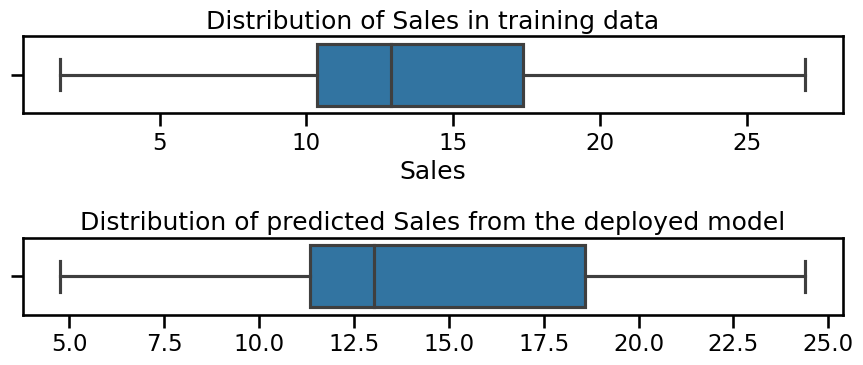

```python
# predictions from AWS enpoint logs(30% synthetic data) Vs the distribution of the target in the training data
plt.figure(figsize=(9, 4))
plt.subplot(211)
sns.boxplot(x='Sales', data=training_data)
plt.title("Distribution of Sales in training data")
plt.subplot(212)
sns.boxplot(x=model_predictions_aws_list)
plt.title("Distribution of predicted Sales from the deployed model")
plt.tight_layout()
plt.show()
```

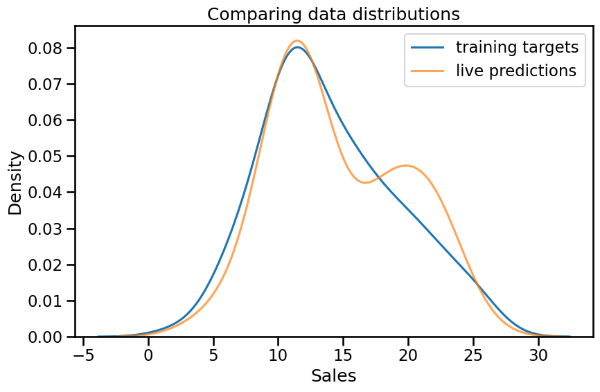

```python
plt.figure(figsize=(9, 6))
sns.kdeplot(x='Sales', data=training_data, label='training targets')
sns.kdeplot(x=model_predictions_aws_list, label='live predictions', alpha=.7)
plt.legend()
plt.title('Comparing data distributions')
plt.tight_layout()
```

**Kolmogorov-Smirnov test**

### Trying to get a more quantitive assessment of the difference between distributions

### Trying to detect a potential drift

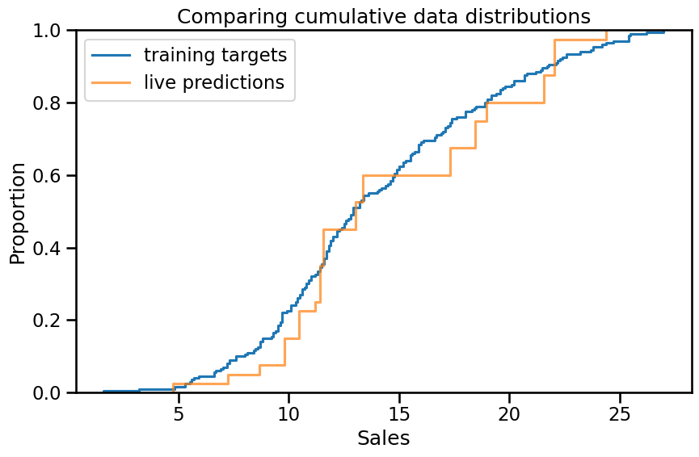

```python
plt.figure(figsize=(9, 6))
sns.ecdfplot(x='Sales', data=training_data, label='training targets')
sns.ecdfplot(x=model_predictions_aws_list, label='live predictions', alpha=.7)
plt.legend()
plt.title('Comparing cumulative data distributions')
plt.tight_layout()
```

```python
training_data['Sales'].shape
```

```
(200,)
```

```python
training_data['Sales'].ndim
```

```
1
```

```python
training_data['Sales'].values
```

```
array([22.1, 10.4,  9.3, 18.5, 12.9,  7.2, 11.8, 13.2,  4.8, 10.6,  8.6,
       17.4,  9.2,  9.7, 19. , 22.4, 12.5, 24.4, 11.3, 14.6, 18. , 12.5,
        5.6, 15.5,  9.7, 12. , 15. , 15.9, 18.9, 10.5, 21.4, 11.9,  9.6,
       17.4,  9.5, 12.8, 25.4, 14.7, 10.1, 21.5, 16.6, 17.1, 20.7, 12.9,
        8.5, 14.9, 10.6, 23.2, 14.8,  9.7, 11.4, 10.7, 22.6, 21.2, 20.2,
       23.7,  5.5, 13.2, 23.8, 18.4,  8.1, 24.2, 15.7, 14. , 18. ,  9.3,
        9.5, 13.4, 18.9, 22.3, 18.3, 12.4,  8.8, 11. , 17. ,  8.7,  6.9,
       14.2,  5.3, 11. , 11.8, 12.3, 11.3, 13.6, 21.7, 15.2, 12. , 16. ,
       12.9, 16.7, 11.2,  7.3, 19.4, 22.2, 11.5, 16.9, 11.7, 15.5, 25.4,
       17.2, 11.7, 23.8, 14.8, 14.7, 20.7, 19.2,  7.2,  8.7,  5.3, 19.8,
       13.4, 21.8, 14.1, 15.9, 14.6, 12.6, 12.2,  9.4, 15.9,  6.6, 15.5,
        7. , 11.6, 15.2, 19.7, 10.6,  6.6,  8.8, 24.7,  9.7,  1.6, 12.7,
        5.7, 19.6, 10.8, 11.6,  9.5, 20.8,  9.6, 20.7, 10.9, 19.2, 20.1,
       10.4, 11.4, 10.3, 13.2, 25.4, 10.9, 10.1, 16.1, 11.6, 16.6, 19. ,
       15.6,  3.2, 15.3, 10.1,  7.3, 12.9, 14.4, 13.3, 14.9, 18. , 11.9,
       11.9,  8. , 12.2, 17.1, 15. ,  8.4, 14.5,  7.6, 11.7, 11.5, 27. ,
       20.2, 11.7, 11.8, 12.6, 10.5, 12.2,  8.7, 26.2, 17.6, 22.6, 10.3,
       17.3, 15.9,  6.7, 10.8,  9.9,  5.9, 19.6, 17.3,  7.6,  9.7, 12.8,
       25.5, 13.4])
```

```python
len(model_predictions_aws_list)
```

```
40
```

```python
statistic, p_value = ks_2samp(
            training_data['Sales'].values,
            model_predictions_aws_list
)
```

Observation

```python
p_value
```

```
0.45823805390287636
```

### *** So far I have run this notebook five times and every time I got the different p-value!!!

```python
min(model_predictions_aws_list)
```

```
4.747782679391745
```

### Null Hypothesis (H0): The distribution of model predictions is the same as the distribution of targets in the training data.

### Alternate Hypothesis (H1): The distribution of model predictions differs from the distribution of targets in the training data.

#### p-value > 0.05 fail to reject the Null Hypotesis, indicating no significant difference in distributions

#### p-value < 0.05 rejecting the Null Hypothesis, suggesting a significance difference between the distributions

## The above p-value is > 0.05, so we fail to reject the Null Hypothesis.

### Data Drift

```python
threshold = 0.05
features_with_data_drift = []
```

Create a loop to check features with data drift

```python
for k, feature in enumerate(sample_Xtest.columns):

    if feature in numeric_features:
        statistic, p_value = ks_2samp(
            training_data[feature].values,
            sample_Xtest[feature].values
        )

        if p_value < threshold:
            features_with_data_drift.append(feature)

    elif feature in categorical_features:
        statistic, p_value, dof, expected = chi2_contingency(
            pd.crosstab(
                training_data[feature],
                sample_Xtest[feature]
            ).values
        )

        if p_value < threshold:
            features_with_data_drift.append(feature)
```

```python
features_with_data_drift
```

```
['Newspaper']
```

Observation:

### The "Newspaper" column has data drift.

.

### Model Drift

Read the advertising_ground_truth.csv file

```python
ground_truth_df = pd.read_csv("s3://vj-milestone-2-project/data/advertising_ground_truth.csv")
```

```python
ground_truth_df.info()
```

```
<class 'pandas.core.frame.DataFrame'>
RangeIndex: 19 entries, 0 to 18
Data columns (total 1 columns):
 #   Column  Non-Null Count  Dtype
---  ------  --------------  -----
 0   Sales   19 non-null     float64
dtypes: float64(1)
memory usage: 280.0 bytes
```

```python
ground_truth_Sales = ground_truth_df
```

```python
len(ground_truth_Sales)
```

```
19
```

```python
ground_truth_Sales.head()
```

|  | Sales |
| --- | --- |
| 0 | 22.1 |
| 1 | 10.4 |
| 2 | 9.3 |
| 3 | 18.5 |
| 4 | 12.9 |

We now present the same synthetic data (on which ground truth is now available) to the endpoint.

```python
response = sagemaker_runtime.invoke_endpoint(
    EndpointName=predictor_gbr.endpoint_name,
    Body=sample_Xtest.to_csv(header=True, index=False).encode("utf-8"),
    ContentType="text/csv"
)
```

```python
model_predictions_aws = ast.literal_eval(
    response["Body"].read().decode("utf-8")
)
```

```python
len(model_predictions_aws)
```

```
19
```

Check the two sample ttest

```python
two_sample_ttest = ttest_rel(model_predictions_aws, ground_truth_Sales['Sales'])
```

```python
two_sample_ttest.pvalue
```

```
0.7916136780794614
```

Observations:

### Since the p-value is > 0.05, we conclude that there is no significance difference between the model predictions and the ground truth

.

## Delete the Endpoint

```python
predictor_gbr.delete_endpoint(delete_endpoint_config=True)
```